# Homework 9 Solutions

## Problem 1 More regression with `mtcars`

In lecture, we worked briefly with the `mtcars` data set. Let’s get more regression practice by working with it some more.

### a) background

Run `?mtcars` in the console (please **do not** add it to this `Rmd` file) and briefly read the help page. Specifically, take note of the following:

1. What is the source of this data?
2. What is this data set measuring (i.e., what was the response variable in the original study, at least based on the brief description in the R documentation)?
3. What predictors are available and what do they mean?

The data came from the 1974 Motor Trend US magazine. In the original study the response variable was fuel consumption (i.e. mpg). The predictors include `cyl` (number of cylinders), `disp` (engine displacement in $in^3$) and others.

You may want to also run `head(mtcars, 10)` or `View(mtcars)` to inspect the data frame briefly before moving on.

### b) Fitting a model

Use `lm` to run a regression of `mpg` on a few predictors in the data frame (choose two or three that you think would make a good model– don’t use all ten; we’ll talk about why in later lectures). Make sure to include `data = mtcars` as a keyword argument to `lm` so that R knows what data frame to use.

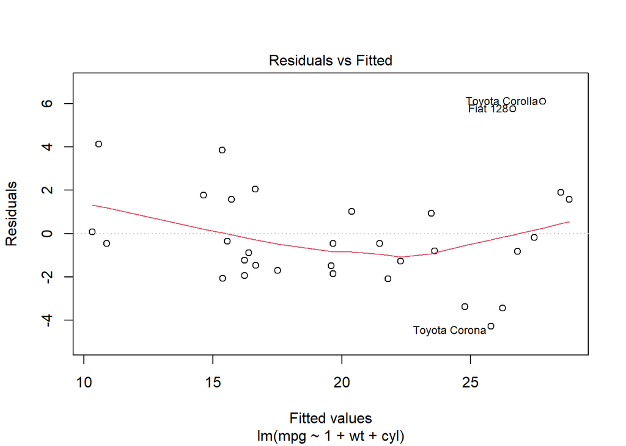

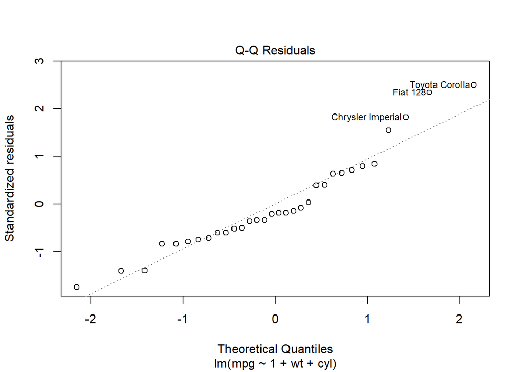

```r
lm.mtcars = lm(mpg ~ 1+ wt + cyl, data=mtcars)
plot(lm.mtcars,ask=F,which=1:2)
```

Briefly inspect the residuals plot by running `plot(lm.mtcars,ask=F,which=1:2)`. What do you observe, and what does it mean?

There are many models that are fine for this problem. Here I used wt and cyl. In this model it seems that there is a noticeable curve in the relationship between residuals and fitted values. This is not what we should see if the linearity assumption is met. The residuals are more or less normally distributed, but the distribution is a bit right-skewed.

### c) Interpreting the model

View the summary of your model by uncommenting and running the code below.

```r
summary(lm.mtcars)
```

```
##
## Call:
## lm(formula = mpg ~ 1 + wt + cyl, data = mtcars)
##
## Residuals:
##     Min      1Q  Median      3Q     Max
## -4.2893 -1.5512 -0.4684  1.5743  6.1004
##
## Coefficients:
##             Estimate Std. Error t value Pr(>|t|)
## (Intercept)  39.6863     1.7150  23.141  < 2e-16 ***
## wt           -3.1910     0.7569  -4.216 0.000222 ***
## cyl          -1.5078     0.4147  -3.636 0.001064 **
## ---
## Signif. codes:  0 '***' 0.001 '**' 0.01 '*' 0.05 '.' 0.1 ' ' 1
##
## Residual standard error: 2.568 on 29 degrees of freedom
## Multiple R-squared:  0.8302, Adjusted R-squared:  0.8185
## F-statistic: 70.91 on 2 and 29 DF,  p-value: 6.809e-12
```

Pick one of your predictors and give an interpretation of the estimate and standard error for its coefficient. Be careful in your wording of the interpretation.

Because wt is in 1000s lbs, the interpretation of the coefficient is that for every 1000 lbs increase in car weight, we expect to see a decrease of 3.191 mpg in fuel efficiency, keeping cyl constant. The standard error of .7569 means that we are very sure that the true coefficient is nonzero - this is seen by looking at the t ratio -3.191/.7569 = -4.216 and its very very small $p$-value, indicating that if the true coefficient was zero it would be almost impossible to collect data like this.

Which coefficients are statistically significantly different from zero? How do you know?

For this model both coefficients and the intercept are significantly different from zero, as can be seen from their extremely low $p$-values.

### d) Interpreting residuals

What is the Residual Standard Error (RSE) for this model? How many degrees of freedom does it have?

The RSE is 2.568 with 29 degrees of freedom for this model.

What is the value of $R^2$ for this model? (**Hint:** look at the output of `summary`) Give an interpretation of this value.

$R^2=.8302$

### e) Adjusted $R^2$

Briefly read about the adjusted $R^2$ [here](https://www.statisticshowto.com/probability-and-statistics/statistics-definitions/adjusted-r2/). What is the adjusted $R^2$ of this model and how does this differ from the usual $R^2$ value? (**Hint:** again, look at the output of `summary`).

The adjusted $R^2$ is .8185, which is a little lower than $R^2$, as is always the case. This statistic is not meaningfully interpreted in isolation, but rather in comparison to another model we can use this statistic to determine if one model does a better job of fitting the data without over-fitting.

### f) CIs for coefficients

Read the documentation for the `confint` function, and use it to generate $95\%$ confidence intervals for the coefficients of your model. Give an interpretation of these confidence intervals.

```r
confint(lm.mtcars)
```

```
##                 2.5 %     97.5 %
## (Intercept) 36.178725 43.1937976
## wt          -4.739020 -1.6429245
## cyl         -2.355928 -0.6596622
```

Notice that all three of these confidence interval live entirely on the positive or the negative side of zero. In other words, we can be 95% confident that each of the parameters in the model are nonzero.

## Problem 2) the `cats` data set

The `cats` data set, included in the `MASS` library, contains data recorded from 144 cats. Each row of the data set contains the body weight (`Bwt`, in kgs), heart weight (`Hwt`, in grams) and the sex (`Sex`, levels `'F'` and `'M'`) for one of the cats in the data set.

### a) plotting the data

Create a scatter plot showing heart weight on the y-axis and body weight on the x-axis. Ignore the `Sex` variable in this plot.

```r
library(MASS)
head(cats)
```

```
##   Sex Bwt Hwt
## 1   F 2.0 7.0
## 2   F 2.0 7.4
## 3   F 2.0 9.5
## 4   F 2.1 7.2
## 5   F 2.1 7.3
## 6   F 2.1 7.6
```

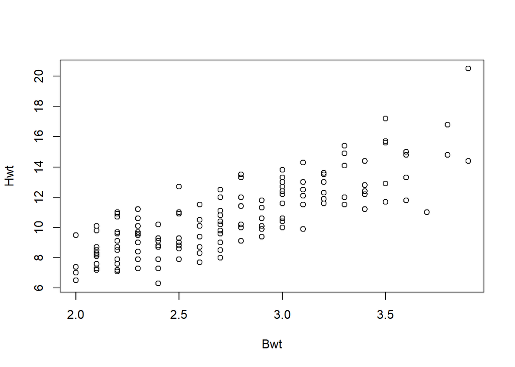

```r
plot(Hwt~Bwt, data=cats)
```

Briefly describe what you see. Is there a clear trend in the data?

There is most certainly a positive relationship between the two variables. ***

### b) fitting a linear model

Fit a linear regression model to predict cat heart weight from cat body weight (and using an intercept term, of course).

```r
catlm <- lm(Hwt~1+Bwt, data=cats)
```

Examine the coefficients of your fitted model. What is the coefficient for the `Bwt` variable? Interpret this coefficient– a unit change in body weight yields how much change in heart weight?

```r
coef(catlm)
```

```
## (Intercept)         Bwt
##  -0.3566624   4.0340627
```

The coefficient is 4.034, meaning that each 1 kg increase in body weight is associated with a 4.034g increase in heart weight.

### c) back to plotting

Create the same plot from Part a above, but this time color the points in the scatter plot according to the `Sex` variable. You may use either `ggplot2` or the built-in R plotting tools, though I would recommend the former, for this.

You should see a clear pattern. Describe it. A sentence or two is fine here.

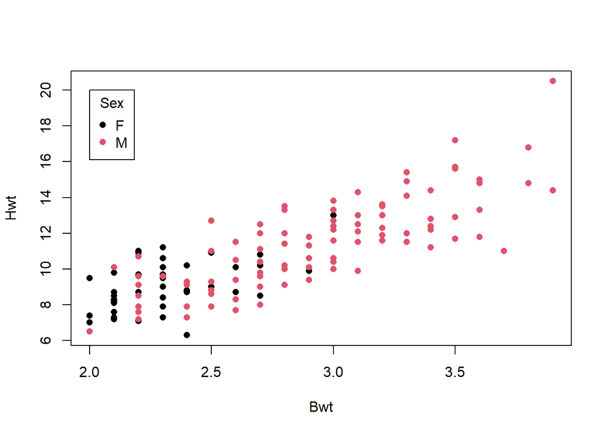

```r
plot(Hwt~Bwt, data=cats, col=Sex, pch=16)
legend(2,20,legend=unique(cats$Sex), col=unique(cats$Sex), pch=16, title="Sex")
```

You notice that the male cats tend to be heavier than the female cats.

### d) adding `Sex` and an interaction

From looking at the data, it should be clear that the `Sex` variable has explanatory power in predicting heart weight, but it is also very correlated with body weight.

Fit a new linear regression model, still predicting heart weight, but this time including both body weight and sex as predictors *and* an interaction term between body weight and sex. Take note of how R assigns `Sex` a dummy encoding.

```r
catlm2 <- lm(Hwt ~ 1 + Bwt * Sex, data=cats)
summary(catlm2)
```

```
##
## Call:
## lm(formula = Hwt ~ 1 + Bwt * Sex, data = cats)
##
## Residuals:
##     Min      1Q  Median      3Q     Max
## -3.7728 -1.0118 -0.1196  0.9272  4.8646
##
## Coefficients:
##             Estimate Std. Error t value Pr(>|t|)
## (Intercept)   2.9813     1.8428   1.618 0.107960
## Bwt           2.6364     0.7759   3.398 0.000885 ***
## SexM         -4.1654     2.0618  -2.020 0.045258 *
## Bwt:SexM      1.6763     0.8373   2.002 0.047225 *
## ---
## Signif. codes:  0 '***' 0.001 '**' 0.01 '*' 0.05 '.' 0.1 ' ' 1
##
## Residual standard error: 1.442 on 140 degrees of freedom
## Multiple R-squared:  0.6566, Adjusted R-squared:  0.6493
## F-statistic: 89.24 on 3 and 140 DF,  p-value: < 2.2e-16
```

Examine the outputs of your model. In particular, note the coefficients of `Sex` and the interaction between `Bwt` and `Sex`. Are both of these coefficients statistically significantly different from zero? How do you interpret the interaction term?

The coefficient of the interaction term is the adjustment to the Bwt coefficient for male cats. ***

## Problem 3 - Using Multiple regression to fit nonlinear data

Open the dataset `multData.csv`. This data set consists of three predictor variables, simply named `X1`, `X2` and `X3`. The response variable is `Y`. In this problem you will explore how to use the multiple regression model to model nonlinear relationships.

### a) the first model

First we will explore the relationship between $Y$ and the first two predictors $X1$ and $X2$. Fit the linear model

$$Y = \beta_0 + \beta_1 X_1 + \beta_2 X_2
+ \epsilon$$
Interpret the coefficients of both X1 and X2.

```r
multData <- read.csv("multData.csv")

fit1 <- lm(Y ~ 1 + X1 + X2, data=multData)
summary(fit1)
```

```
##
## Call:
## lm(formula = Y ~ 1 + X1 + X2, data = multData)
##
## Residuals:
##     Min      1Q  Median      3Q     Max
## -12.512  -5.586  -1.030   4.607  13.248
##
## Coefficients:
##             Estimate Std. Error t value Pr(>|t|)
## (Intercept) 860.5679    53.3533  16.130  < 2e-16 ***
## X1           -6.7573     0.1699 -39.767  < 2e-16 ***
## X2          -22.8693     3.4903  -6.552 3.91e-08 ***
## ---
## Signif. codes:  0 '***' 0.001 '**' 0.01 '*' 0.05 '.' 0.1 ' ' 1
##
## Residual standard error: 6.602 on 47 degrees of freedom
## Multiple R-squared:  0.9758, Adjusted R-squared:  0.9748
## F-statistic: 949.1 on 2 and 47 DF,  p-value: < 2.2e-16
```

A 1 unit increase in X1 (keeping X2 constant) is associated with a 6.75 decrease in Y.

A 1 unit increase in X2 (keeping X1 constant) is associated with a 22.869 decrease in Y.

### b) Investigating interaction of quantitative predictors

Next introduce an interaction term to the model
$$Y = \beta_0 + \beta_1 X_1 + \beta_2 X_2 + \beta_3
X_1\cdot X_2 + \epsilon$$

Fit the model and view the summary output. Has this improved the model fit? Did anything surprising happen to the coefficients? Try to explain what happened.

```r
fit2 <- lm(Y ~ 1 + X1 * X2, data=multData)
summary(fit2)
```

```
##
## Call:
## lm(formula = Y ~ 1 + X1 * X2, data = multData)
##
## Residuals:
##      Min       1Q   Median       3Q      Max
## -11.4217  -4.2752   0.6041   4.2966  11.9496
##
## Coefficients:
##             Estimate Std. Error t value Pr(>|t|)
## (Intercept) 172.7879   166.9912   1.035  0.30621
## X1           27.4350     7.9875   3.435  0.00127 **
## X2           21.5155    10.7876   1.994  0.05205 .
## X1:X2        -2.2036     0.5147  -4.281 9.34e-05 ***
## ---
## Signif. codes:  0 '***' 0.001 '**' 0.01 '*' 0.05 '.' 0.1 ' ' 1
##
## Residual standard error: 5.643 on 46 degrees of freedom
## Multiple R-squared:  0.9827, Adjusted R-squared:  0.9816
## F-statistic: 872.1 on 3 and 46 DF,  p-value: < 2.2e-16
```

Residual standard error has decreased, and Adjusted R squared has increased - thus from those two standpoints the model fit has improved. Surprisingly now the coefficients of both X1 and X2 are positive now. The negative effect of increasing these variables seems to be entirely attributable to the interaction term which has a negative coefficient.

### c) Introducing the last predictor

Next fit a model that introduces the `X3` variable.

$$Y = \beta_0 + \beta_1 X_1 + \beta_2 X_2
+ \beta_3 X_1\cdot X_2 + \beta_4 X_3 \epsilon$$
Has the model fit improved? In what way (Justify your answer)?

```r
fit3 <- lm(Y ~ 1 + X1 * X2+X3, data=multData)
summary(fit3)
```

```
##
## Call:
## lm(formula = Y ~ 1 + X1 * X2 + X3, data = multData)
##
## Residuals:
##      Min       1Q   Median       3Q      Max
## -1.90027 -0.55128 -0.00481  0.66250  2.25369
##
## Coefficients:
##              Estimate Std. Error t value Pr(>|t|)
## (Intercept) 119.01881   31.89702   3.731 0.000532 ***
## X1           26.58555    1.52412  17.443  < 2e-16 ***
## X2           20.97950    2.05820  10.193 2.85e-13 ***
## X3           60.26613    1.72630  34.910  < 2e-16 ***
## X1:X2        -2.14656    0.09821 -21.857  < 2e-16 ***
## ---
## Signif. codes:  0 '***' 0.001 '**' 0.01 '*' 0.05 '.' 0.1 ' ' 1
##
## Residual standard error: 1.077 on 45 degrees of freedom
## Multiple R-squared:  0.9994, Adjusted R-squared:  0.9993
## F-statistic: 1.827e+04 on 4 and 45 DF,  p-value: < 2.2e-16
```

Residual standard error has been decreased greatly to 1.077, and the Adjusted R squared has increased dramatically. The introduction of $X3$ has greatly improved the model fit.

### d) Considering higher order terms

Finally explore higher order terms for the X3 variable: Introduce $X3^2$, $X3^3$ etc and determine if any of these higher order terms are justified in the model. Explain your reasoning and present your final model. Look at the diagnostic plots and discuss whether the assumptions of the multiple regression model seem to be justified.

```r
fit4 <- lm(Y ~ 1 + X1 * X2+X3+I(X3^2), data=multData)
summary(fit4)
```

```
##
## Call:
## lm(formula = Y ~ 1 + X1 * X2 + X3 + I(X3^2), data = multData)
##
## Residuals:
##     Min      1Q  Median      3Q     Max
## -1.9336 -0.7616  0.1374  0.4654  2.0767
##
## Coefficients:
##              Estimate Std. Error t value Pr(>|t|)
## (Intercept)  61.14664   33.24919   1.839  0.07266 .
## X1           26.55470    1.36910  19.396  < 2e-16 ***
## X2           21.02276    1.84886  11.371 1.10e-14 ***
## X3          172.98782   32.89344   5.259 4.08e-06 ***
## I(X3^2)     -55.02379   16.03870  -3.431  0.00132 **
## X1:X2        -2.14488    0.08822 -24.313  < 2e-16 ***
## ---
## Signif. codes:  0 '***' 0.001 '**' 0.01 '*' 0.05 '.' 0.1 ' ' 1
##
## Residual standard error: 0.9671 on 44 degrees of freedom
## Multiple R-squared:  0.9995, Adjusted R-squared:  0.9995
## F-statistic: 1.812e+04 on 5 and 44 DF,  p-value: < 2.2e-16
```

```r
fit5 <- lm(Y ~ 1 + X1 * X2+X3+I(X3^2)+I(X3^3), data=multData)
summary(fit5)
```

```
##
## Call:
## lm(formula = Y ~ 1 + X1 * X2 + X3 + I(X3^2) + I(X3^3), data = multData)
##
## Residuals:
##     Min      1Q  Median      3Q     Max
## -1.9512 -0.7661  0.1539  0.4828  2.0949
##
## Coefficients:
##              Estimate Std. Error t value Pr(>|t|)
## (Intercept)   33.7306   192.7321   0.175    0.862
## X1            26.6078     1.4326  18.573  < 2e-16 ***
## X2            21.0861     1.9205  10.979  4.7e-14 ***
## X3           251.0709   541.5214   0.464    0.645
## I(X3^2)     -131.4880   529.5410  -0.248    0.805
## I(X3^3)       24.8233   171.8291   0.144    0.886
## X1:X2         -2.1483     0.0923 -23.275  < 2e-16 ***
## ---
## Signif. codes:  0 '***' 0.001 '**' 0.01 '*' 0.05 '.' 0.1 ' ' 1
##
## Residual standard error: 0.9781 on 43 degrees of freedom
## Multiple R-squared:  0.9995, Adjusted R-squared:  0.9994
## F-statistic: 1.476e+04 on 6 and 43 DF,  p-value: < 2.2e-16
```

We see further improvement to both RSE and Adj R squared when introducing the squared term, but then a degredation of model fit when we introduce the third power term. Furthermore, all 3 $X3$ terms are no longer significant in the 3rd order model. Thus we would opt to stick with the linear and squared terms.

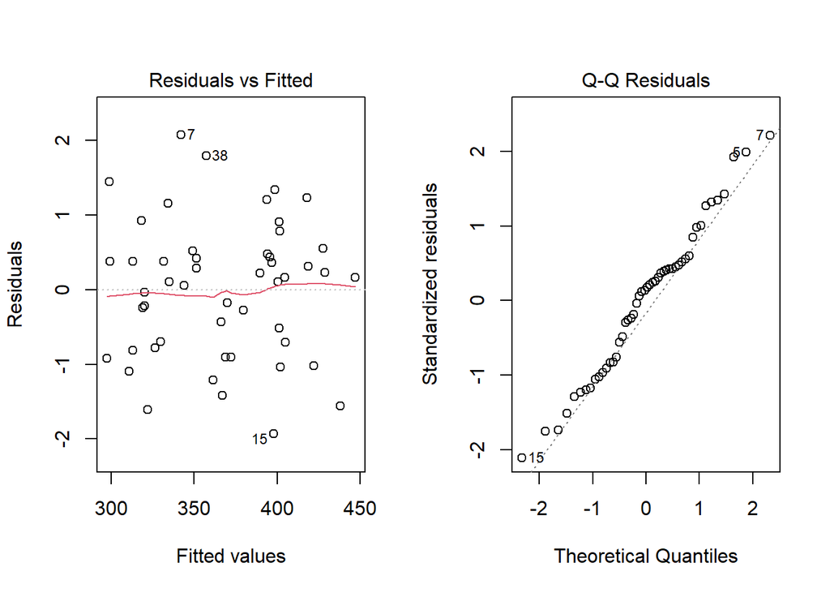

```r
par(mfrow=c(1,2))
plot(fit4, which=1:2)
```

```r
par(mfrow=c(1,1))
```